# Análisis Estadístico y ML del Titanic

Author

Fabrizio Torrico

Published

May 7, 2025

[figure not shown]

This kernel is for all aspiring data scientists to learn from and to review their knowledge. We will have a detailed statistical analysis of Titanic data set along with Machine learning model implementation. I am super excited to share my first kernel with the Kaggle community. As I go on in this journey and learn new topics, I will incorporate them with each new updates. So, check for them and please **leave a comment** if you have any suggestions to make this kernel better!! Going back to the topics of this kernel, I will do more in-depth visualizations to explain the data, and the machine learning classifiers will be used to predict passenger survival status.

NOTE:

- This is a julia translation
- If you are reading this on github, I recommend you read this on [kaggle](https://www.kaggle.com/masumrumi/a-statistical-analysis-ml-workflow-of-titanic)
- Follow me on github:

# Kernel Goals

There are three primary goals of this kernel.

- **Do a statistical analysis** of how some group of people was survived more than others.
- **Do an exploratory data analysis(EDA)** of titanic with visualizations and storytelling.
- **Predict**: Use machine learning classification models to predict the chances of passengers survival.

P.S. If you want to learn more about regression models, try this [kernel](https://www.kaggle.com/masumrumi/a-stats-analysis-and-ml-workflow-of-house-pricing/edit/run/9585160).

# Part 1: Importing Necessary Libraries and datasets

## 1a. Loading libraries

Python is a fantastic language with a vibrant community that produces many amazing libraries. I am not a big fan of importing everything at once for the newcomers. So, I am going to introduce a few necessary libraries for now, and as we go on, we will keep unboxing new libraries when it seems appropriate.

```julia
using Pkg
Pkg.activate(".")
Pkg.add(["IJulia", "DataFrames", "CSV", "CairoMakie", "StatsBase",
         "Statistics", "MLJ", "MLJModels", "MLJBase", "HypothesisTests",
         "Distributions", "Missings", "CategoricalArrays", "AlgebraOfGraphics", "Chain"])
```

[output not shown]

```julia
import DataFrames as DF
import CSV
import CairoMakie as Makie
import AlgebraOfGraphics as AoG
import Statistics as Stats
import StatsBase
import Chain: @chain
import Random: shuffle
import IJulia
```

:::

```julia
readdir("./input/")
```

```
3-element Vector{String}:
 "gender_submission.csv"
 "test.csv"
 "train.csv"
```

## 1b. Loading Datasets

After loading the necessary modules, we need to import the datasets. Many of the business problems usually come with a tremendous amount of messy data. We extract those data from many sources. I am hoping to write about that in a different kernel. For now, we are going to work with a less complicated and quite popular machine learning dataset.

```julia
## Importing the datasets
using CSV

train = CSV.read("./input/train.csv", DF.DataFrame)
test = CSV.read("./input/test.csv", DF.DataFrame);
```

You are probably wondering why two datasets? Also, Why have I named it “train” and “test”? To explain that I am going to give you an overall picture of the supervised machine learning process.

“Machine Learning” is simply “Machine” and “Learning”. Nothing more and nothing less. In a supervised machine learning process, we are giving machine/computer/models specific inputs or data(text/number/image/audio) to learn from aka we are training the machine to learn certain aspects based on the data and the output. Now, how can we determine that machine is actually learning what we are try to teach? That is where the test set comes to play. We withhold part of the data where we know the output/result of each datapoints, and we use this data to test the trained models. We then compare the outcomes to determine the performance of the algorithms. If you are a bit confused thats okay. I will explain more as we keep reading. Let’s take a look at sample datasets.

```julia
DF.first(train, 5)
```

5×12 DataFrame

| Row | PassengerId Int64 | Survived Int64 | Pclass Int64 | Name String | Sex String7 | Age Float64? | SibSp Int64 | Parch Int64 | Ticket String31 | Fare Float64 | Cabin String15? | Embarked String1? |
| --- | --- | --- | --- | --- | --- | --- | --- | --- | --- | --- | --- | --- |
| 1 | 1 | 0 | 3 | Braund, Mr. Owen Harris | male | 22.0 | 1 | 0 | A/5 21171 | 7.25 | missing | S |
| 2 | 2 | 1 | 1 | Cumings, Mrs. John Bradley (Florence Briggs Thayer) | female | 38.0 | 1 | 0 | PC 17599 | 71.2833 | C85 | C |
| 3 | 3 | 1 | 3 | Heikkinen, Miss. Laina | female | 26.0 | 0 | 0 | STON/O2. 3101282 | 7.925 | missing | S |
| 4 | 4 | 1 | 1 | Futrelle, Mrs. Jacques Heath (Lily May Peel) | female | 35.0 | 1 | 0 | 113803 | 53.1 | C123 | S |
| 5 | 5 | 0 | 3 | Allen, Mr. William Henry | male | 35.0 | 0 | 0 | 373450 | 8.05 | missing | S |

```julia
@chain train begin
    DF.dropmissing(:Age) # Drop rows with missing Age
    DF.groupby(:Sex)
    DF.combine(:Age => minimum => :MinAge)
end
```

2×2 DataFrame

| Row | Sex String7 | MinAge Float64 |
| --- | --- | --- |
| 1 | male | 0.42 |
| 2 | female | 0.75 |

```julia
DF.describe(train, :eltype)
```

12×2 DataFrame

| Row | variable Symbol | eltype Type |
| --- | --- | --- |
| 1 | PassengerId | Int64 |
| 2 | Survived | Int64 |
| 3 | Pclass | Int64 |
| 4 | Name | String |
| 5 | Sex | String7 |
| 6 | Age | Union{Missing, Float64} |
| 7 | SibSp | Int64 |
| 8 | Parch | Int64 |
| 9 | Ticket | String31 |
| 10 | Fare | Float64 |
| 11 | Cabin | Union{Missing, String15} |
| 12 | Embarked | Union{Missing, String1} |

## 1c. A Glimpse of the Datasets.

# Train Set

```julia
DF.first(train[shuffle(1:DF.nrow(train))[1:5], :], 5)
```

5×12 DataFrame

| Row | PassengerId Int64 | Survived Int64 | Pclass Int64 | Name String | Sex String7 | Age Float64? | SibSp Int64 | Parch Int64 | Ticket String31 | Fare Float64 | Cabin String15? | Embarked String1? |
| --- | --- | --- | --- | --- | --- | --- | --- | --- | --- | --- | --- | --- |
| 1 | 575 | 0 | 3 | Rush, Mr. Alfred George John | male | 16.0 | 0 | 0 | A/4. 20589 | 8.05 | missing | S |
| 2 | 439 | 0 | 1 | Fortune, Mr. Mark | male | 64.0 | 1 | 4 | 19950 | 263.0 | C23 C25 C27 | S |
| 3 | 111 | 0 | 1 | Porter, Mr. Walter Chamberlain | male | 47.0 | 0 | 0 | 110465 | 52.0 | C110 | S |
| 4 | 570 | 1 | 3 | Jonsson, Mr. Carl | male | 32.0 | 0 | 0 | 350417 | 7.8542 | missing | S |
| 5 | 802 | 1 | 2 | Collyer, Mrs. Harvey (Charlotte Annie Tate) | female | 31.0 | 1 | 1 | C.A. 31921 | 26.25 | missing | S |

# Test Set

```julia
DF.first(test[shuffle(1:DF.nrow(test))[1:5], :], 5)
```

5×11 DataFrame

| Row | PassengerId Int64 | Pclass Int64 | Name String | Sex String7 | Age Float64? | SibSp Int64 | Parch Int64 | Ticket String31 | Fare Float64? | Cabin String15? | Embarked String1 |
| --- | --- | --- | --- | --- | --- | --- | --- | --- | --- | --- | --- |
| 1 | 1261 | 2 | Pallas y Castello, Mr. Emilio | male | 29.0 | 0 | 0 | SC/PARIS 2147 | 13.8583 | missing | C |
| 2 | 1238 | 2 | Botsford, Mr. William Hull | male | 26.0 | 0 | 0 | 237670 | 13.0 | missing | S |
| 3 | 986 | 1 | Birnbaum, Mr. Jakob | male | 25.0 | 0 | 0 | 13905 | 26.0 | missing | C |
| 4 | 1007 | 3 | Chronopoulos, Mr. Demetrios | male | 18.0 | 1 | 0 | 2680 | 14.4542 | missing | C |
| 5 | 900 | 3 | Abrahim, Mrs. Joseph (Sophie Halaut Easu) | female | 18.0 | 0 | 0 | 2657 | 7.2292 | missing | C |

This is a sample of train and test dataset. Lets find out a bit more about the train and test dataset.

```julia
println("The shape of the train data is (row, column): $(size(train))")
println("Train dataset info:")
DF.describe(train)


println("The shape of the test data is (row, column): $(size(test))")
println("Test dataset info:")
DF.describe(test)
```

```
The shape of the train data is (row, column): (891, 12)
Train dataset info:
The shape of the test data is (row, column): (418, 11)
Test dataset info:
```

11×7 DataFrame

| Row | variable Symbol | mean Union… | min Any | median Union… | max Any | nmissing Int64 | eltype Type |
| --- | --- | --- | --- | --- | --- | --- | --- |
| 1 | PassengerId | 1100.5 | 892 | 1100.5 | 1309 | 0 | Int64 |
| 2 | Pclass | 2.26555 | 1 | 3.0 | 3 | 0 | Int64 |
| 3 | Name |  | Abbott, Master. Eugene Joseph |  | van Billiard, Master. Walter John | 0 | String |
| 4 | Sex |  | female |  | male | 0 | String7 |
| 5 | Age | 30.2726 | 0.17 | 27.0 | 76.0 | 86 | Union{Missing, Float64} |
| 6 | SibSp | 0.447368 | 0 | 0.0 | 8 | 0 | Int64 |
| 7 | Parch | 0.392344 | 0 | 0.0 | 9 | 0 | Int64 |
| 8 | Ticket |  | 110469 |  | W.E.P. 5734 | 0 | String31 |
| 9 | Fare | 35.6272 | 0.0 | 14.4542 | 512.329 | 1 | Union{Missing, Float64} |
| 10 | Cabin |  | A11 |  | G6 | 327 | Union{Missing, String15} |
| 11 | Embarked |  | C |  | S | 0 | String1 |

## 1d. About This Dataset

The data has split into two groups:

- training set (train.csv)
- test set (test.csv)

*The training set includes our target variable(dependent variable), passenger survival status* (also known as the ground truth from the Titanic tragedy) along with other independent features like gender, class, fare, and Pclass.

The test set should be used to see how well our model performs on unseen data. When we say unseen data, we mean that the algorithm or machine learning models have no relation to the test data. We do not want to use any part of the test data in any way to modify our algorithms; Which are the reasons why we clean our test data and train data separately. *The test set does not provide passengers survival status*. We are going to use our model to predict passenger survival status.

Now let’s go through the features and describe a little. There is a couple of different type of variables, They are…

**Categorical:**

- **Nominal**(variables that have two or more categories, but which do not have an intrinsic order.) > - **Cabin** > - **Embarked**(Port of Embarkation) C(Cherbourg) Q(Queenstown) S(Southampton)
- **Dichotomous**(Nominal variable with only two categories) > - **Sex** Female Male
- **Ordinal**(variables that have two or more categories just like nominal variables. Only the categories can also be ordered or ranked.) > - **Pclass** (A proxy for socio-economic status (SES)) 1(Upper) 2(Middle) 3(Lower)

**Numeric:**

- **Discrete** > - **Passenger ID**(Unique identifing # for each passenger) > - **SibSp** > - **Parch** > - **Survived** (Our outcome or dependent variable) 0 1
- **Continous** > - **Age** > - **Fare**

**Text Variable**

> - **Ticket** (Ticket number for passenger.)
> - **Name**( Name of the passenger.)

## 1e. Tableau Visualization of the Data

I have incorporated a tableau visualization below of the training data. This visualization…

- is for us to have an overview and play around with the dataset.
- is done without making any changes(including Null values) to any features of the dataset.

Let’s get a better perspective of the dataset through this visualization.

[figure not shown]

We want to see how the left vertical bar changes when we filter out unique values of certain features. We can use multiple filters to see if there are any correlations among them. For example, if we click on **upper** and **Female** tab, we would see that green color dominates the bar with a ratio of 91:3 survived and non survived female passengers; a 97% survival rate for females. We can reset the filters by clicking anywhere in the whilte space. The age distribution chart on top provides us with some more info such as, what was the age range of those three unlucky females as the red color give away the unsurvived once. If you would like to check out some of my other tableau charts, please click [here.](https://public.tableau.com/profile/masum.rumi#!/)

# Part 2: Overview and Cleaning the Data

## 2a. Overview

Datasets in the real world are often messy, However, this dataset is almost clean. Lets analyze and see what we have here.

```julia
DF.describe(train, :nmissing, :eltype)
```

12×3 DataFrame

| Row | variable Symbol | nmissing Int64 | eltype Type |
| --- | --- | --- | --- |
| 1 | PassengerId | 0 | Int64 |
| 2 | Survived | 0 | Int64 |
| 3 | Pclass | 0 | Int64 |
| 4 | Name | 0 | String |
| 5 | Sex | 0 | String7 |
| 6 | Age | 177 | Union{Missing, Float64} |
| 7 | SibSp | 0 | Int64 |
| 8 | Parch | 0 | Int64 |
| 9 | Ticket | 0 | String31 |
| 10 | Fare | 0 | Float64 |
| 11 | Cabin | 687 | Union{Missing, String15} |
| 12 | Embarked | 2 | Union{Missing, String1} |

:::

It looks like, the features have unequal amount of data entries for every column and they have many different types of variables. This can happen for the following reasons…

- We may have missing values in our features.
- We may have categorical features.
- We may have alphanumerical or/and text features.

## 2b. Dealing with Missing values

**Missing values in *train* dataset.**

```julia
function missing_percentage(df::DF.DataFrame)
    """This function takes a DataFrame as input and returns total missing values and percentages"""
    missing_counts = [count(ismissing, df[!, col]) for col in DF.names(df)]
    missing_pct = round.(missing_counts ./ DF.nrow(df) .* 100, digits=2)

    # Create result DataFrame
    result = DF.DataFrame(
        Column = DF.names(df),
        Total = missing_counts,
        Percent = missing_pct
    )

    # Sort by total missing values (descending)
    return DF.sort(result, :Total, rev=true)
end
```

```
missing_percentage (generic function with 1 method)
```

:::

```julia
missing_percentage(train)
```

12×3 DataFrame

| Row | Column String | Total Int64 | Percent Float64 |
| --- | --- | --- | --- |
| 1 | Cabin | 687 | 77.1 |
| 2 | Age | 177 | 19.87 |
| 3 | Embarked | 2 | 0.22 |
| 4 | PassengerId | 0 | 0.0 |
| 5 | Survived | 0 | 0.0 |
| 6 | Pclass | 0 | 0.0 |
| 7 | Name | 0 | 0.0 |
| 8 | Sex | 0 | 0.0 |
| 9 | SibSp | 0 | 0.0 |
| 10 | Parch | 0 | 0.0 |
| 11 | Ticket | 0 | 0.0 |
| 12 | Fare | 0 | 0.0 |

**Missing values in *test* set.**

```julia
missing_percentage(test)
```

11×3 DataFrame

| Row | Column String | Total Int64 | Percent Float64 |
| --- | --- | --- | --- |
| 1 | Cabin | 327 | 78.23 |
| 2 | Age | 86 | 20.57 |
| 3 | Fare | 1 | 0.24 |
| 4 | PassengerId | 0 | 0.0 |
| 5 | Pclass | 0 | 0.0 |
| 6 | Name | 0 | 0.0 |
| 7 | Sex | 0 | 0.0 |
| 8 | SibSp | 0 | 0.0 |
| 9 | Parch | 0 | 0.0 |
| 10 | Ticket | 0 | 0.0 |
| 11 | Embarked | 0 | 0.0 |

:::

We see that in both **train**, and **test** dataset have missing values. Let’s make an effort to fill these missing values starting with “Embarked” feature.

### Embarked feature

```julia
function percent_value_counts(df::DF.DataFrame, feature::Symbol)
    """This function takes a dataframe and a column and finds the percentage of the value_counts"""

    # Count values including missing
    counts = DF.combine(DF.groupby(df, feature), DF.nrow => :Total)

    # Calculate percentages
    counts.Percent = round.(counts.Total ./ DF.nrow(df) .* 100, digits=2)

    # Sort by total count (descending)
    return DF.sort(counts, :Total, rev=true)
end
```

```
percent_value_counts (generic function with 1 method)
```

:::

```julia
percent_value_counts(train, :Embarked)
```

4×3 DataFrame

| Row | Embarked String1? | Total Int64 | Percent Float64 |
| --- | --- | --- | --- |
| 1 | S | 644 | 72.28 |
| 2 | C | 168 | 18.86 |
| 3 | Q | 77 | 8.64 |
| 4 | missing | 2 | 0.22 |

:::

It looks like there are only two null values( ~ 0.22 %) in the Embarked feature, we can replace these with the mode value “S”. However, let’s dig a little deeper.

**Let’s see what are those two null values**

```julia
train[ismissing.(train.Embarked), :]
```

2×12 DataFrame

| Row | PassengerId Int64 | Survived Int64 | Pclass Int64 | Name String | Sex String7 | Age Float64? | SibSp Int64 | Parch Int64 | Ticket String31 | Fare Float64 | Cabin String15? | Embarked String1? |
| --- | --- | --- | --- | --- | --- | --- | --- | --- | --- | --- | --- | --- |
| 1 | 62 | 1 | 1 | Icard, Miss. Amelie | female | 38.0 | 0 | 0 | 113572 | 80.0 | B28 | missing |
| 2 | 830 | 1 | 1 | Stone, Mrs. George Nelson (Martha Evelyn) | female | 62.0 | 0 | 0 | 113572 | 80.0 | B28 | missing |

:::

We may be able to solve these two missing values by looking at other independent variables of the two raws. Both passengers paid a fare of $80, are of Pclass 1 and female Sex. Let’s see how the **Fare** is distributed among all **Pclass** and **Embarked** feature values

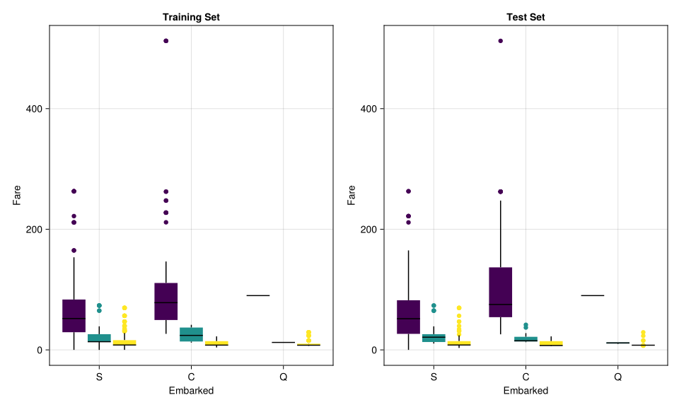

```julia
fig = Makie.Figure()

# Prepare data for plotting
train_clean = DF.dropmissing(train, [:Embarked, :Fare, :Pclass])
test_clean = DF.dropmissing(test, [:Embarked, :Fare, :Pclass])

# Create mapping for embarked ports to numbers
unique_categories = unique(train_clean.Embarked)
category_to_index = Dict(category => i for (i, category) in enumerate(unique_categories))
# Convert categorical to numeric
train_clean.Embarked_num = [category_to_index[port] for port in train_clean.Embarked]
test_clean.Embarked_num = [category_to_index[port] for port in test_clean.Embarked]

# Training set boxplot
ax1 = Makie.Axis(fig[1, 1],
    title = "Training Set",
    xlabel = "Embarked",
    ylabel = "Fare",
    xticks = (1:3, unique_categories)
)

ax2 = Makie.Axis(fig[1, 2],
    title = "Test Set",
    xlabel = "Embarked",
    ylabel = "Fare",
    xticks = (1:3, unique_categories)
)

Makie.boxplot!(ax2, test_clean.Embarked_num, test_clean.Fare,
           dodge = test_clean.Pclass,
           color = test_clean.Pclass)
Makie.boxplot!(ax1, train_clean.Embarked_num, train_clean.Fare,
           dodge = train_clean.Pclass,
           color = train_clean.Pclass)

fig
```

:::

Here, in both training set and test set, the average fare closest to $80 are in the **C** Embarked values where pclass is 1. So, let’s fill in the missing values as “C”

```julia
## Replacing the null values in the Embarked column with the mode.
train.Embarked = coalesce.(train.Embarked, "C");
```

:::

### Cabin Feature

```julia
println("Train Cabin missing: $(count(ismissing, train.Cabin) / DF.nrow(train))")
println("Test Cabin missing: $(count(ismissing, test.Cabin) / DF.nrow(test))")
```

```
Train Cabin missing: 0.7710437710437711
Test Cabin missing: 0.7822966507177034
```

:::

Approximately 77% of Cabin feature is missing in the training data and 78% missing on the test data. We have two choices,

- we can either get rid of the whole feature, or
- we can brainstorm a little and find an appropriate way to put them in use. For example, We may say passengers with cabin record had a higher socio-economic-status then others. We may also say passengers with cabin record were more likely to be taken into consideration when loading into the boat.

Let’s combine train and test data first and for now, will assign all the null values as **“N”**

```julia
survivors = train.Survived
DF.select!(train, DF.Not(:Survived))  # Remove Survived column
all_data = vcat(train, test)

all_data.Cabin = coalesce.(all_data.Cabin, "N");
```

:::

All the cabin names start with an English alphabet following by multiple digits. It seems like there are some passengers that had booked multiple cabin rooms in their name. This is because many of them travelled with family. However, they all seem to book under the same letter followed by different numbers. It seems like there is a significance with the letters rather than the numbers. Therefore, we can group these cabins according to the letter of the cabin name.

```julia
all_data.Cabin = [string(cabin[1]) for cabin in all_data.Cabin];
```

:::

Now let’s look at the value counts of the cabin features and see how it looks.

```julia
percent_value_counts(all_data, :Cabin)
```

9×3 DataFrame

| Row | Cabin String | Total Int64 | Percent Float64 |
| --- | --- | --- | --- |
| 1 | N | 1014 | 77.46 |
| 2 | C | 94 | 7.18 |
| 3 | B | 65 | 4.97 |
| 4 | D | 46 | 3.51 |
| 5 | E | 41 | 3.13 |
| 6 | A | 22 | 1.68 |
| 7 | F | 21 | 1.6 |
| 8 | G | 5 | 0.38 |
| 9 | T | 1 | 0.08 |

:::

So, We still haven’t done any effective work to replace the null values. Let’s stop for a second here and think through how we can take advantage of some of the other features here.

- We can use the average of the fare column We can use pythons *groupby* function to get the mean fare of each cabin letter.

```julia
@chain all_data begin
    DF.dropmissing(:Fare)
    DF.groupby(:Cabin)
    DF.combine(:Fare => Stats.mean => :Mean_Fare)
    DF.sort(:Mean_Fare)
end
```

9×2 DataFrame

| Row | Cabin String | Mean_Fare Float64 |
| --- | --- | --- |
| 1 | G | 14.205 |
| 2 | F | 18.0794 |
| 3 | N | 19.1327 |
| 4 | T | 35.5 |
| 5 | A | 41.2443 |
| 6 | D | 53.0073 |
| 7 | E | 54.5646 |
| 8 | C | 107.927 |
| 9 | B | 122.383 |

:::

Now, these means can help us determine the unknown cabins, if we compare each unknown cabin rows with the given mean’s above. Let’s write a simple function so that we can give cabin names based on the means.

```julia
function cabin_estimator(fare::Union{Float64, Missing})
    """Grouping cabin feature by the first letter based on fare"""
    # Handle missing values
    if ismissing(fare)
        return "N"  # Default cabin for missing fare
    end

    if fare < 16
        return "G"
    elseif 16 ≤ fare < 27
        return "F"
    elseif 27 ≤ fare < 38
        return "T"
    elseif 38 ≤ fare < 47
        return "A"
    elseif 47 ≤ fare < 53
        return "E"
    elseif 53 ≤ fare < 54
        return "D"
    elseif 54 ≤ fare < 116
        return "C"
    else
        return "B"
    end
end
```

```
cabin_estimator (generic function with 1 method)
```

:::

Let’s apply **cabin_estimator** function in each unknown cabins(cabin with **null** values). Once that is done we will separate our train and test to continue towards machine learning modeling.

```julia
with_N = all_data[all_data.Cabin .== "N", :]
without_N = all_data[all_data.Cabin .!= "N", :];
```

```julia
with_N.Cabin = cabin_estimator.(with_N.Fare)

# Combine back together
all_data = vcat(with_N, without_N)

# Sort by PassengerId
DF.sort!(all_data, :PassengerId)

# Separate train and test
train = all_data[1:891, :]
test = all_data[892:end, :]

# Add back survival information
train.Survived = survivors;
```

:::

### Fare Feature

If you have paid attention so far, you know that there is only one missing value in the fare column. Let’s have it.

```julia
test[ismissing.(test.Fare), :]
```

1×11 DataFrame

| Row | PassengerId Int64 | Pclass Int64 | Name String | Sex String7 | Age Float64? | SibSp Int64 | Parch Int64 | Ticket String31 | Fare Float64? | Cabin String | Embarked Abstract… |
| --- | --- | --- | --- | --- | --- | --- | --- | --- | --- | --- | --- |
| 1 | 1044 | 3 | Storey, Mr. Thomas | male | 60.5 | 0 | 0 | 3701 | missing | N | S |

Here, We can take the average of the **Fare** column to fill in the NaN value. However, for the sake of learning and practicing, we will try something else. We can take the average of the values where**Pclass** is *3*, **Sex** is *male* and **Embarked** is *S*

```julia
missing_value = @chain test begin
    DF.subset(:Pclass => x -> x .== 3, :Embarked => x -> x .== "S", :Sex => x -> x .== "male")
    _.Fare
    skipmissing
    Stats.mean
end

test.Fare = coalesce.(test.Fare, missing_value);
```

:::

### Age Feature

We know that the feature “Age” is the one with most missing values, let’s see it in terms of percentage.

```julia
println("Train age missing value: $(round(count(ismissing, train.Age) / DF.nrow(train) * 100, digits=2))%")
println("Test age missing value: $(round(count(ismissing, test.Age) / DF.nrow(test) * 100, digits=2))%")
```

```
Train age missing value: 19.87%
Test age missing value: 20.57%
```

:::

We will take a different approach since **~20% data in the Age column is missing** in both train and test dataset. The age variable seems to be promising for determining survival rate. Therefore, It would be unwise to replace the missing values with median, mean or mode. We will use machine learning model Random Forest Regressor to impute missing value instead of Null value. We will keep the age column unchanged for now and work on that in the feature engineering section.

# Part 3. Visualization and Feature Relations

Before we dive into finding relations between independent variables and our dependent variable(survivor), let us create some assumptions about how the relations may turn-out among features.

**Assumptions:**

- Gender: More female survived than male
- Pclass: Higher socio-economic status passenger survived more than others.
- Age: Younger passenger survived more than other passengers.
- Fare: Passenger with higher fare survived more that other passengers. This can be quite correlated with Pclass.

Now, let’s see how the features are related to each other by creating some visualizations.

## 3a. Gender and Survived

```julia
Makie.set_theme!(Makie.theme_light())
```

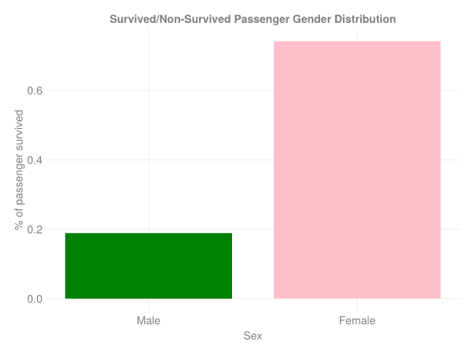

```julia
fig = Makie.Figure()
ax = Makie.Axis(fig[1, 1],
    title = "Survived/Non-Survived Passenger Gender Distribution",
    xlabel = "Sex",
    ylabel = "% of passenger survived",
    xticks= (1:2, ["Male", "Female"]),

)

# Calculate survival rates by gender
survival_by_sex = @chain train begin
    DF.groupby(:Sex)
    DF.combine(:Survived => Stats.mean => :survival_rate)
    DF.sort(:Sex, rev=true)  # Female first
end

# Create elegant barplot
Makie.barplot!(ax, 1:2, survival_by_sex.survival_rate,
           color = ["green", "pink"])

fig
```

This bar plot above shows the distribution of female and male survived. The *x_label* represents **Sex** feature while the *y_label* represents the % of **passenger survived**. This bar plot shows that ~74% female passenger survived while only ~19% male passenger survived.

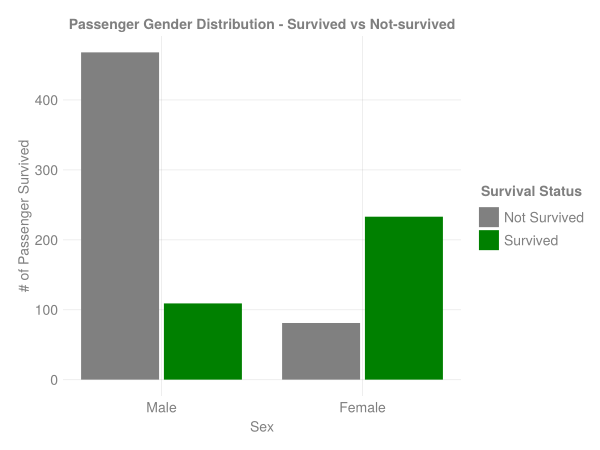

```julia
fig = Makie.Figure()
ax = Makie.Axis(fig[1, 1],
    title = "Passenger Gender Distribution - Survived vs Not-survived",
    xlabel = "Sex",
    ylabel = "# of Passenger Survived",
    xticks = (1:2, ["Male", "Female"])
)

# Count data for grouped bar chart
count_data = @chain train begin
    DF.groupby([:Sex, :Survived])
    DF.combine(DF.nrow => :count)
    DF.unstack(:Survived, :count, fill=0)
end

# Create grouped bar chart
counts = [count_data[1, 2], count_data[1, 3], count_data[2, 2], count_data[2, 3]]


Makie.barplot!(ax, [1, 1, 2, 2], counts,
           dodge = [1, 2, 1,2],
           color = ["gray", "green", "gray", "green"])



# Add legend
Makie.Legend(fig[1, 2],
    [Makie.PolyElement(color = "gray"), Makie.PolyElement(color = "green")],
    ["Not Survived", "Survived"],
    "Survival Status")

fig
```

This count plot shows the actual distribution of male and female passengers that survived and did not survive. It shows that among all the females ~ 230 survived and ~ 70 did not survive. While among male passengers ~110 survived and ~480 did not survive.

**Summary**

- As we suspected, female passengers have survived at a much better rate than male passengers.
- It seems about right since females and children were the priority.

## 3b. Pclass and Survived

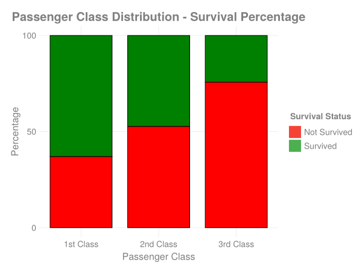

```julia
fig = Makie.Figure()
ax = Makie.Axis(fig[1, 1],
    title = "Passenger Class Distribution - Survival Percentage",
    xlabel = "Passenger Class",
    ylabel = "Percentage",
    titlesize = 20,
    xlabelsize = 16,
    ylabelsize = 16,
    xticks=(1:3, ["1st Class", "2nd Class", "3rd Class"])
)

# Calculate percentages by class
class_survival = @chain train begin
    DF.groupby([:Pclass, :Survived])
    DF.combine(DF.nrow => :count)
    DF.unstack(:Survived, :count, fill=0)
end

no_survived = class_survival[:, 2]
yes_survived = class_survival[:, 3]
total_by_class = no_survived + yes_survived

survived_percentage = (yes_survived ./ total_by_class) * 100
not_survived_percentage = (no_survived ./ total_by_class) * 100

flatten = vcat(not_survived_percentage ,survived_percentage)

Makie.barplot!(ax, [1, 2, 3, 1, 2, 3], flatten, stack=[1, 2, 3, 1, 2, 3], color = ["red", "red", "red", "green", "green", "green"], strokewidth = 1, strokecolor = :black)

# Add legend
Makie.Legend(fig[1, 2],
    [Makie.PolyElement(color = "#F44336"), Makie.PolyElement(color = "#4CAF50")],
    ["Not Survived", "Survived"],
    "Survival Status")

fig
```

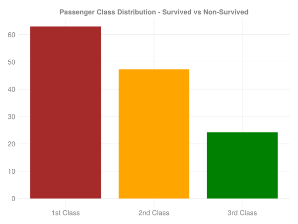

```julia
Makie.barplot([1, 2, 3], survived_percentage, axis=(xticks=(1:3, ["1st Class", "2nd Class", "3rd Class"]), title = "Passenger Class Distribution - Survived vs Non-Survived"), color=["brown", "orange", "green"])
```

- It looks like …
  - ~ 63% first class passenger survived titanic tragedy, while
  - ~ 48% second class and
  - ~ only 24% third class passenger survived.

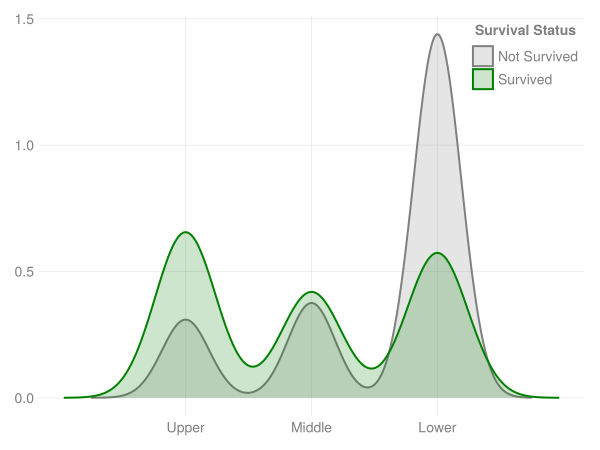

```julia
fig = Makie.Figure(
    title = "Passenger Class Distribution - Survived vs Non-Survived",
    xlabel = "Passenger Class",
    ylabel = "Density of Passenger Survived",
) # Adjust figure size as needed
ax =  Makie.Axis(fig[1, 1], xticks = ([1, 2, 3], ["Upper", "Middle", "Lower"]))

d1 = Makie.density!(ax, train.Pclass[train.Survived .== 0], color = (:gray, 0.2), strokecolor=:gray, strokewidth=2)

d2= Makie.density!(ax, train.Pclass[train.Survived .== 1], color = (:green, 0.2), strokecolor=:green, strokewidth=2)

Makie.axislegend(ax,
    [d1, d2],
    ["Not Survived", "Survived"],
    "Survival Status")

fig
```

This KDE plot is pretty self-explanatory with all the labels and colors. Something I have noticed that some readers might find questionable is that the lower class passengers have survived more than second-class passengers. It is true since there were a lot more third-class passengers than first and second.

**Summary**

The first class passengers had the upper hand during the tragedy. You can probably agree with me more on this, in the next section of visualizations where we look at the distribution of ticket fare and survived column.

## 3c. Fare and Survived

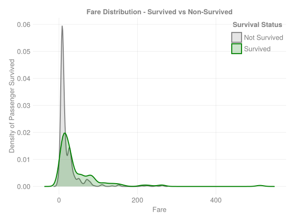

```julia
fig = Makie.Figure()

ax = Makie.Axis(fig[1, 1],
    title = "Fare Distribution - Survived vs Non-Survived",
    xlabel = "Fare",
    ylabel = "Density of Passenger Survived",
)

d1 = Makie.density!(ax, train.Fare[train.Survived .== 0], color = (:gray, 0.2), strokecolor=:gray, strokewidth=2)
d2 = Makie.density!(ax, train.Fare[train.Survived .== 1], color = (:green, 0.2), strokecolor=:green, strokewidth=2)

Makie.axislegend(ax,
    [d1, d2],
    ["Not Survived", "Survived"],
    "Survival Status")
fig
```

This plot shows something impressive..

- The spike in the plot under 100 dollar represents that a lot of passengers who bought the ticket within that range did not survive.
- When fare is approximately more than 280 dollars, there is no gray shade which means, either everyone passed that fare point survived or maybe there is an outlier that clouds our judgment. Let’s check…

```julia
train[train.Fare .> 280, :]
```

3×12 DataFrame

| Row | PassengerId Int64 | Pclass Int64 | Name String | Sex String7 | Age Float64? | SibSp Int64 | Parch Int64 | Ticket String31 | Fare Float64? | Cabin String | Embarked Abstract… | Survived Int64 |
| --- | --- | --- | --- | --- | --- | --- | --- | --- | --- | --- | --- | --- |
| 1 | 259 | 1 | Ward, Miss. Anna | female | 35.0 | 0 | 0 | PC 17755 | 512.329 | B | C | 1 |
| 2 | 680 | 1 | Cardeza, Mr. Thomas Drake Martinez | male | 36.0 | 0 | 1 | PC 17755 | 512.329 | B | C | 1 |
| 3 | 738 | 1 | Lesurer, Mr. Gustave J | male | 35.0 | 0 | 0 | PC 17755 | 512.329 | B | C | 1 |

As we assumed, it looks like an outlier with a fare of $512. We sure can delete this point. However, we will keep it for now.

## 3d. Age and Survived

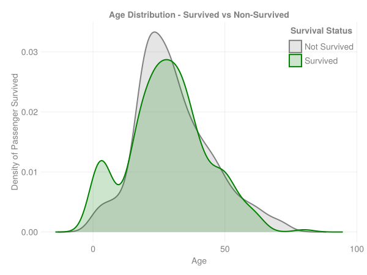

```julia
fig = Makie.Figure()

ax = Makie.Axis(fig[1, 1], title = "Age Distribution - Survived vs Non-Survived",
    xlabel = "Age",
    ylabel = "Density of Passenger Survived")


# clean missing first
clean_train =  DF.dropmissing(train, :Age)
not_survived = clean_train.Age[clean_train.Survived .== 0]
survived = clean_train.Age[clean_train.Survived .== 1]

d1 = Makie.density!(ax, not_survived, color = (:gray, 0.2), strokecolor=:gray, strokewidth=2)
d2 = Makie.density!(ax, survived, color = (:green, 0.2), strokecolor=:green, strokewidth=2)

Makie.axislegend(ax,
    [d1, d2],
    ["Not Survived", "Survived"],
    "Survival Status")

fig
```

There is nothing out of the ordinary about this plot, except the very left part of the distribution. This may hint on the posibility that children and infants were the priority.

## 3e. Combined Feature Relations

In this section, we are going to discover more than two feature relations in a single graph. I will try my best to illustrate most of the feature relations. Let’s get to it.

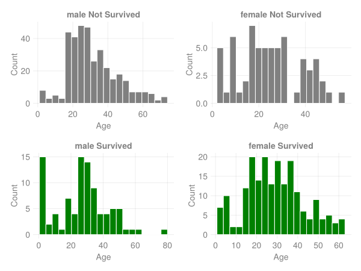

```julia
fig = Makie.Figure(title="Survived by Sex and Age")

# Create subplots for each combination

for (i, (sex, survived)) in enumerate(Iterators.product(["female", "male"], [0, 1]))

    ax = Makie.Axis(fig[div(i - 1, 2) + 1, i % 2 + 1],
        title = "$sex $(survived == 1 ? "Survived" : "Not Survived")",
        xlabel = "Age",
        ylabel = "Count"
    )

    subset_data = train[(train.Sex .== sex) .& (train.Survived .== survived) .& .!ismissing.(train.Age), :]

    Makie.hist!(ax, subset_data.Age, bins = 20,
            color = survived == 1 ? "green" : "gray",
            strokewidth = 1, strokecolor = :white)

end

fig
```

Facetgrid is a great way to visualize multiple variables and their relationships at once. From the chart in section 3a we have a intuation that female passengers had better prority than males during the tragedy. However, from this facet grid, we can also understand which age range groups survived more than others or were not so lucky

```
Length of subset: 53
Length of subset: 133
Length of subset: 300
Length of subset: 68
Length of subset: 6
Length of subset: 57
Length of subset: 45
Length of subset: 24
Length of subset: 5
Length of subset: 7
Length of subset: 15
Length of subset: 1
```

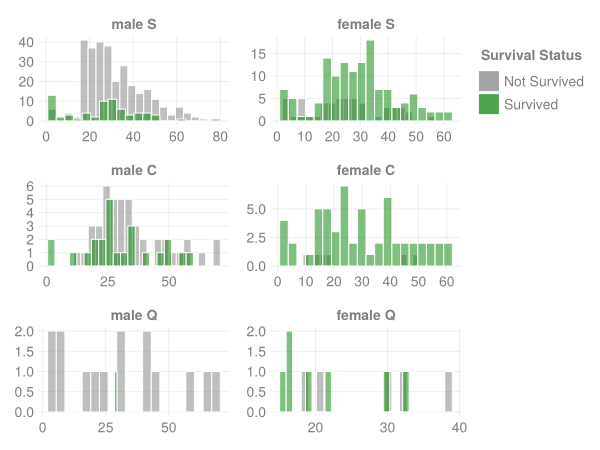

```julia
fig = Makie.Figure(title="Survived by Sex and Age")

# Create subplots for each combination
for (i, (sex, embarked)) in enumerate(Iterators.product(["female", "male"], ["S", "C", "Q"]))

    ax = Makie.Axis(fig[div(i - 1, 2) + 1, i % 2 + 1],
        title = "$sex $embarked",
    )

    subset_data = train[(train.Sex .== sex) .& (train.Embarked .== embarked) .& .!ismissing.(train.Age), :]

    for (survived) in [0, 1]
        subset_survived = subset_data[(subset_data.Survived .== survived), :]
        println("Length of subset: $(DF.nrow(subset_survived))")

        if DF.nrow(subset_data) > 0
             Makie.hist!(ax, subset_survived.Age,
                        bins = 20,
                        color = survived == 1 ? (:green, 0.5) : (:gray, 0.5),
                        strokewidth = 1,
                        strokecolor = :white,
                        label = survived == 1 ? "Survived" : "Not Survived"
                    )
        end
    end
end


Makie.Legend(fig[1, 3],
    [Makie.PolyElement(color = (:gray, 0.7)),
     Makie.PolyElement(color = (:green, 0.7))],
    ["Not Survived", "Survived"],
    "Survival Status"
)

fig
```

This is another compelling facet grid illustrating four features relationship at once. They are **Embarked, Age, Survived & Sex**.

- The color illustrates passengers survival status(green represents survived, gray represents not survived)
- The column represents Sex(left being male, right stands for female)
- The row represents Embarked(from top to bottom: S, C, Q)

Now that I have steered out the apparent let’s see if we can get some insights that are not so obvious as we look at the data.

- Most passengers seem to be boarded on Southampton(S).
- More than 60% of the passengers died boarded on Southampton.
- More than 60% of the passengers lived boarded on Cherbourg(C).
- Pretty much every male that boarded on Queenstown(Q) did not survive.
- There were very few females boarded on Queenstown, however, most of them survived.

[output not shown]

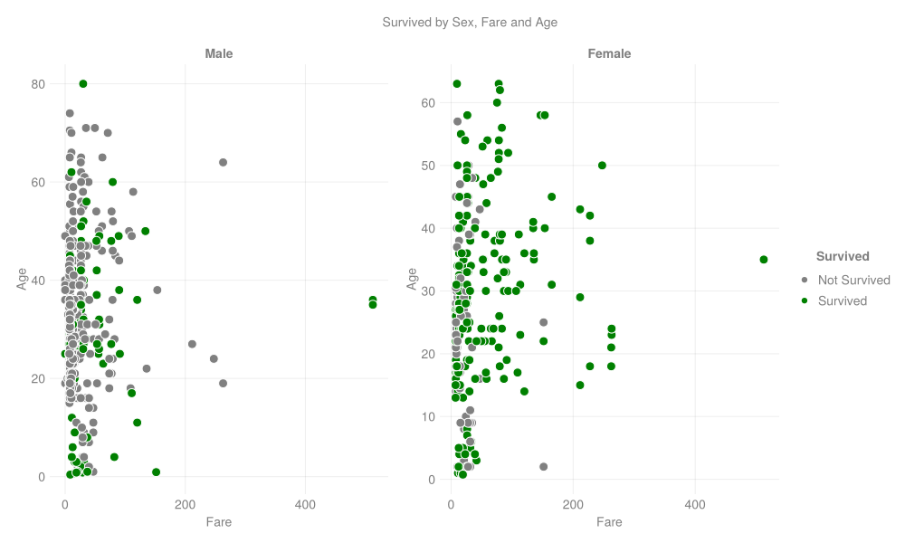

```julia
fig = Makie.Figure(resolution = (1000, 600))

ax_m = Makie.Axis(fig[1, 1],
    title = "Male",
    xlabel = "Fare",
    ylabel = "Age")
# Female subplot
ax_f = Makie.Axis(fig[1, 2],
    title = "Female",
    xlabel = "Fare",
    ylabel = "Age")

female_data = train[(train.Sex .== "female") .& .!ismissing.(train.Age), :]
male_data = train[(train.Sex .== "male") .& .!ismissing.(train.Age), :]


Makie.scatter!(ax_m, male_data.Fare, male_data.Age,
           color = [s == 1 ? "green" : "gray" for s in male_data.Survived],
           strokewidth=1, strokecolor="white", markersize=14)
Makie.scatter!(ax_f, female_data.Fare, female_data.Age,
           color = [s == 1 ? "green" : "gray" for s in female_data.Survived],
           strokewidth=1, strokecolor="white", markersize=14)


# Add legend
Makie.Legend(fig[1, 3],
    [Makie.MarkerElement(color = "gray", marker = :circle),
     Makie.MarkerElement(color = "green", marker = :circle)],
    ["Not Survived", "Survived"],
    "Survived")

Makie.Label(fig[0, :], "Survived by Sex, Fare and Age")
fig
```

This facet grid unveils a couple of interesting insights. Let’s find out.

- The grid above clearly demonstrates the three outliers with Fare of over $500. At this point, I think we are quite confident that these outliers should be deleted.
- Most of the passengers were with in the Fare range of $100.

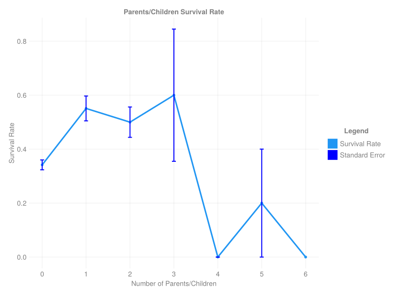

```julia
train = train[train.Fare .< 500, :]

fig = Makie.Figure(size = (800, 600))
ax = Makie.Axis(fig[1, 1],
    title = "Parents/Children Survival Rate",
    xlabel = "Number of Parents/Children",
    ylabel = "Survival Rate",
)

parch_survival = @chain train_clean begin
    DF.groupby(:Parch)
    DF.combine(
        :Survived => Stats.mean => :survival_rate,
        :Survived => Stats.std => :std_dev,
        :Survived => length => :count
    )
end

parch_survival.std_error = parch_survival.std_dev ./ sqrt.(parch_survival.count)

Makie.scatterlines!(ax, parch_survival.Parch, parch_survival.survival_rate,
    color = "#2196F3",
    linewidth = 3,
    markersize = 8
)

error = Makie.errorbars!(ax, parch_survival.Parch, parch_survival.survival_rate,
    parch_survival.std_error,
    color = "blue",
    linewidth = 2,
    whiskerwidth = 8
)

Makie.Legend(fig[1, 2],
    [Makie.PolyElement(color = "#2196F3"), Makie.PolyElement(color = "blue")],
    ["Survival Rate", "Standard Error"],
    "Legend"
)
fig
```

**Passenger who traveled in big groups with parents/children had less survival rate than other passengers.**

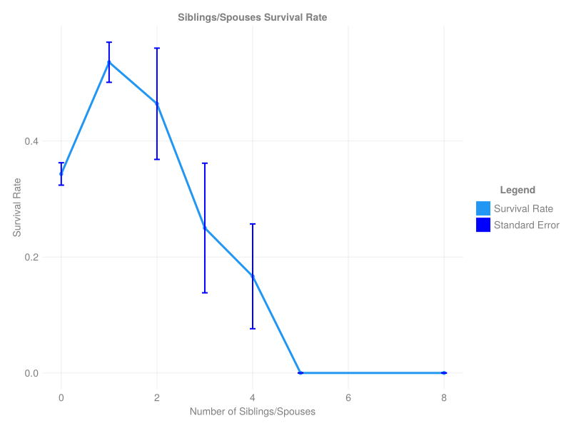

```julia
fig = Makie.Figure(size = (800, 600))
ax = Makie.Axis(fig[1, 1],
    title = "Siblings/Spouses Survival Rate",
    xlabel = "Number of Siblings/Spouses",
    ylabel = "Survival Rate",
)

sibsp_survival = @chain train_clean begin
    DF.groupby(:SibSp)
    DF.combine(
        :Survived => Stats.mean => :survival_rate,
        :Survived => Stats.std => :std_dev,
        :Survived => length => :count
    )
end

sibsp_survival.std_error = sibsp_survival.std_dev ./ sqrt.(sibsp_survival.count)

Makie.scatterlines!(ax, sibsp_survival.SibSp, sibsp_survival.survival_rate,
    color = "#2196F3",
    linewidth = 3,
    markersize = 8
)

error = Makie.errorbars!(ax, sibsp_survival.SibSp, sibsp_survival.survival_rate,
    sibsp_survival.std_error,
    color = "blue",
    linewidth = 2,
    whiskerwidth = 8
)

Makie.Legend(fig[1, 2],
    [Makie.PolyElement(color = "#2196F3"), Makie.PolyElement(color = "blue")],
    ["Survival Rate", "Standard Error"],
    "Legend"
)
fig
```

**While, passenger who traveled in small groups with sibilings/spouses had better changes of survivint than other passengers.**

```julia
train.Sex = [sex == "female" ? 0 : 1 for sex in train.Sex]
test.Sex = [sex == "female" ? 0 : 1 for sex in test.Sex];
```

# Part 4: Statistical Overview

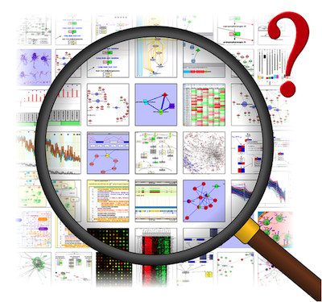

title

**Train info**

```julia
DF.describe(train)
```

12×7 DataFrame

| Row | variable Symbol | mean Union… | min Any | median Union… | max Any | nmissing Int64 | eltype Type |
| --- | --- | --- | --- | --- | --- | --- | --- |
| 1 | PassengerId | 445.618 | 1 | 445.5 | 891 | 0 | Int64 |
| 2 | Pclass | 2.31306 | 1 | 3.0 | 3 | 0 | Int64 |
| 3 | Name |  | Abbing, Mr. Anthony |  | van Melkebeke, Mr. Philemon | 0 | String |
| 4 | Sex | 0.647523 | 0 | 1.0 | 1 | 0 | Int64 |
| 5 | Age | 29.6753 | 0.42 | 28.0 | 80.0 | 177 | Union{Missing, Float64} |
| 6 | SibSp | 0.524775 | 0 | 0.0 | 8 | 0 | Int64 |
| 7 | Parch | 0.381757 | 0 | 0.0 | 6 | 0 | Int64 |
| 8 | Ticket |  | 110152 |  | WE/P 5735 | 0 | String31 |
| 9 | Fare | 30.5822 | 0.0 | 14.4542 | 263.0 | 0 | Union{Missing, Float64} |
| 10 | Cabin |  | A |  | T | 0 | String |
| 11 | Embarked |  | C |  | S | 0 | AbstractString |
| 12 | Survived | 0.381757 | 0 | 0.0 | 1 | 0 | Int64 |

```julia
categorical_cols = [col for col in names(train) if eltype(train[!, col]) <: Union{String, AbstractString}]
DF.describe(train[!, categorical_cols])
```

4×7 DataFrame

| Row | variable Symbol | mean Nothing | min Abstract… | median Nothing | max Abstract… | nmissing Int64 | eltype DataType |
| --- | --- | --- | --- | --- | --- | --- | --- |
| 1 | Name |  | Abbing, Mr. Anthony |  | van Melkebeke, Mr. Philemon | 0 | String |
| 2 | Ticket |  | 110152 |  | WE/P 5735 | 0 | String31 |
| 3 | Cabin |  | A |  | T | 0 | String |
| 4 | Embarked |  | C |  | S | 0 | AbstractString |

```julia
survived_summary = @chain train begin
    DF.select(DF.names(train, Number)...)
    DF.groupby(:Survived)
    DF.combine(DF.All() .=> Stats.mean)
end
```

2×7 DataFrame

| Row | Survived Int64 | PassengerId_mean Float64 | Pclass_mean Float64 | Sex_mean Float64 | SibSp_mean Float64 | Parch_mean Float64 | Survived_mean Float64 |
| --- | --- | --- | --- | --- | --- | --- | --- |
| 1 | 0 | 447.016 | 2.53188 | 0.852459 | 0.553734 | 0.32969 | 0.0 |
| 2 | 1 | 443.354 | 1.9587 | 0.315634 | 0.477876 | 0.466077 | 1.0 |

```julia
sex_summary = @chain train begin
    DF.select(DF.names(train, Number)...)
    DF.groupby(:Sex)
    DF.combine(DF.All() .=> Stats.mean)
end
```

2×7 DataFrame

| Row | Sex Int64 | PassengerId_mean Float64 | Pclass_mean Float64 | Sex_mean Float64 | SibSp_mean Float64 | Parch_mean Float64 | Survived_mean Float64 |
| --- | --- | --- | --- | --- | --- | --- | --- |
| 1 | 0 | 431.578 | 2.16294 | 0.0 | 0.696486 | 0.651757 | 0.741214 |
| 2 | 1 | 453.261 | 2.39478 | 1.0 | 0.431304 | 0.234783 | 0.186087 |

```julia
class_summary = @chain train begin
    DF.select(DF.names(train, Number)...)
    DF.groupby(:Pclass)
    DF.combine(DF.All() .=> Stats.mean)
end
```

3×7 DataFrame

| Row | Pclass Int64 | PassengerId_mean Float64 | Pclass_mean Float64 | Sex_mean Float64 | SibSp_mean Float64 | Parch_mean Float64 | Survived_mean Float64 |
| --- | --- | --- | --- | --- | --- | --- | --- |
| 1 | 1 | 460.225 | 1.0 | 0.56338 | 0.422535 | 0.356808 | 0.624413 |
| 2 | 2 | 445.957 | 2.0 | 0.586957 | 0.402174 | 0.380435 | 0.472826 |
| 3 | 3 | 439.155 | 3.0 | 0.706721 | 0.615071 | 0.393075 | 0.242363 |

I have gathered a small summary from the statistical overview above. Let’s see what they are…

## 4a. Correlation Matrix and Heatmap

### Correlations

```julia
train_clean = DF.dropmissing(train)
train_numeric = DF.select(train_clean, DF.names(train_clean, Number)...)
corr_matrix = Stats.cor(Stats.Matrix(train_numeric))

corr_df = DF.DataFrame(corr_matrix, DF.names(train_numeric))
```

8×8 DataFrame

| Row | PassengerId Float64 | Pclass Float64 | Sex Float64 | Age Float64 | SibSp Float64 | Parch Float64 | Fare Float64 | Survived Float64 |
| --- | --- | --- | --- | --- | --- | --- | --- | --- |
| 1 | 1.0 | -0.0329038 | 0.0211665 | 0.0361809 | -0.0816053 | -0.0122084 | -0.00823828 | 0.0272982 |
| 2 | -0.0329038 | 1.0 | 0.156916 | -0.368625 | 0.0641473 | 0.0250993 | -0.617708 | -0.354847 |
| 3 | 0.0211665 | 0.156916 | 1.0 | 0.0932959 | -0.104071 | -0.248746 | -0.232061 | -0.541935 |
| 4 | 0.0361809 | -0.368625 | 0.0932959 | 1.0 | -0.307639 | -0.189194 | 0.100396 | -0.0794722 |
| 5 | -0.0816053 | 0.0641473 | -0.104071 | -0.307639 | 1.0 | 0.384056 | 0.196907 | -0.014598 |
| 6 | -0.0122084 | 0.0250993 | -0.248746 | -0.189194 | 0.384056 | 1.0 | 0.258878 | 0.0942578 |
| 7 | -0.00823828 | -0.617708 | -0.232061 | 0.100396 | 0.196907 | 0.258878 | 1.0 | 0.275122 |
| 8 | 0.0272982 | -0.354847 | -0.541935 | -0.0794722 | -0.014598 | 0.0942578 | 0.275122 | 1.0 |

```julia
DF.sort(DF.DataFrame(
    Variable = DF.names(corr_df),
    Correlation = abs.(corr_df[!, :Survived])
), [:Correlation], rev=true)
```

8×2 DataFrame

| Row | Variable String | Correlation Float64 |
| --- | --- | --- |
| 1 | Survived | 1.0 |
| 2 | Sex | 0.541935 |
| 3 | Pclass | 0.354847 |
| 4 | Fare | 0.275122 |
| 5 | Parch | 0.0942578 |
| 6 | Age | 0.0794722 |
| 7 | PassengerId | 0.0272982 |
| 8 | SibSp | 0.014598 |

** Sex is the most important correlated feature with *Survived(dependent variable)* feature followed by Pclass.**

```julia
DF.sort(DF.DataFrame(
    Variable = DF.names(corr_df),
    Correlation = abs.(corr_df[!, :Survived]) .^ 2
), [:Correlation], rev=true)
```

8×2 DataFrame

| Row | Variable String | Correlation Float64 |
| --- | --- | --- |
| 1 | Survived | 1.0 |
| 2 | Sex | 0.293693 |
| 3 | Pclass | 0.125916 |
| 4 | Fare | 0.0756923 |
| 5 | Parch | 0.00888453 |
| 6 | Age | 0.00631583 |
| 7 | PassengerId | 0.000745194 |
| 8 | SibSp | 0.000213103 |

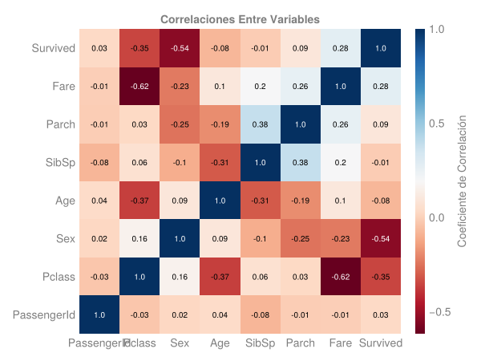

```julia
n = size(corr_df, 1)

fig = Makie.Figure()
ax = Makie.Axis(fig[1, 1],
    title = "Correlaciones Entre Variables",
    xticks=((1:n), DF.names(corr_df)),
    yticks=((1:n), DF.names(corr_df)),
)

hm = Makie.heatmap!(ax, (1:n), (1:n), corr_matrix, colormap="RdBu")

for i in 1:n
    for j in 1:n
        text_val = corr_matrix[j, i]

        Makie.text!(ax, i, j,
            text = string(round(text_val, digits=2)),
            color = abs(text_val) > 0.5 ? :white : :black,
            fontsize = 10,
            align = (:center, :center)
        )
    end
end

Makie.Colorbar(fig[1, 2], hm,
    label = "Coeficiente de Correlación",
)

fig
```

#### Negative Correlation Features:

However, the most significant correlation with our dependent variable is the Sex variable, which is the info on whether the passenger was male or female. This negative correlation with a magnitude of -0.54 which points towards some undeniable insights. Let’s do some statistics to see how statistically significant this correlation is.

## 4b. Statistical Test for Correlation

Statistical tests are the scientific way to prove the validation of theories. In any case, when we look at the data, we seem to have an intuitive understanding of where data is leading us. However, when we do statistical tests, we get a scientific or mathematical perspective of how significant these results are. Let’s apply some of these methods and see how we are doing with our predictions.

### Hypothesis Testing Outline

A hypothesis test compares the mean of a control group and experimental group and tries to find out whether the two sample means are different from each other and if they are different, how significant that difference is.

A **hypothesis test** usually consists of multiple parts:

1. Formulate a well-developed research problem or question: The hypothesis test usually starts with a concrete and well-developed researched problem. We need to ask the right question that can be answered using statistical analysis.
2. **The null hypothesis($H_0$) and Alternating hypothesis($H_1$)**: > - The **null hypothesis($H_0$)** is something that is assumed to be true. It is the status quo. In a null hypothesis, the observations are the result of pure chance. When we set out to experiment, we form the null hypothesis by saying that there is no difference between the means of the control group and the experimental group. > - An **Alternative hypothesis($H_A$)** is a claim and the opposite of the null hypothesis. It is going against the status quo. In an alternative theory, the observations show a real effect combined with a component of chance variation.
3. Determine the **test statistic**: test statistic can be used to assess the truth of the null hypothesis. Depending on the standard deviation we either use t-statistics or z-statistics. In addition to that, we want to identify whether the test is a one-tailed test or two-tailed test. [This](https://support.minitab.com/en-us/minitab/18/help-and-how-to/statistics/basic-statistics/supporting-topics/basics/null-and-alternative-hypotheses/) article explains it pretty well. [This](https://stattrek.com/hypothesis-test/hypothesis-testing.aspx) article is pretty good as well.
4. Specify a **Significance level** and **Confidence Interval**: The significance level($\alpha$) is the probability of rejecting a null hypothesis when it is true. In other words, we are *comfortable/confident* with rejecting the null hypothesis a significant amount of times even though it is true. This considerable amount is our Significant level. In addition to that, Significance level is one minus our Confidence interval. For example, if we say, our significance level is 5%, then our confidence interval would be (1 - 0.05) = 0.95 or 95%.
5. Compute the **T-Statistics/Z-Statistics**: Computing the t-statistics follows a simple equation. This equation slightly differs depending on one sample test or two sample test
6. Compute the **P-value**: P-value is the probability that a test statistic at least as significant as the one observed would be obtained assuming that the null hypothesis is correct. The p-value is known to be unintuitive, and even many professors are known to explain it wrong. I think this [video](https://www.youtube.com/watch?v=E4KCfcVwzyw) explains the p-value well. **The smaller the P-value, the stronger the evidence against the null hypothesis.**
7. **Describe the result and compare the p-value with the significance value($\alpha$)**: If p<=$\alpha$, then the observed effect is statistically significant, the null hypothesis is ruled out, and the alternative hypothesis is valid. However if the p> $\alpha$, we say that, we fail to reject the null hypothesis. Even though this sentence is grammatically wrong, it is logically right. We never accept the null hypothesis just because we are doing the statistical test with sample data points.

We will follow each of these steps above to do your hypothesis testing below.

P.S. Khan Academy has a set of videos that I think are intuative and helped me understand conceptually.

### Hypothesis testing for Titanic

#### Formulating a well developed researched question:

Regarding this dataset, we can formulate the null hypothesis and alternative hypothesis by asking the following questions.

> - **Is there a significant difference in the mean sex between the passenger who survived and passenger who did not survive?**.
> - **Is there a substantial difference in the survival rate between the male and female passengers?**

#### The Null Hypothesis and The Alternative Hypothesis:

We can formulate our hypothesis by asking questions differently. However, it is essential to understand what our end goal is. Here our dependent variable or target variable is **Survived**. Therefore, we say

> ** Null Hypothesis($H_0$):** There is no difference in the survival rate between the male and female passengers. or the mean difference between male and female passenger in the survival rate is zero.  
> ** Alternative Hypothesis($H_A$):** There is a difference in the survival rate between the male and female passengers. or the mean difference in the survival rate between male and female is not zero.

Onc thing we can do is try to set up the Null and Alternative Hypothesis in such way that, when we do our t-test, we can choose to do one tailed test. According to [this](https://support.minitab.com/en-us/minitab/18/help-and-how-to/statistics/basic-statistics/supporting-topics/basics/null-and-alternative-hypotheses/) article, one-tailed tests are more powerful than two-tailed test. In addition to that, [this](https://www.youtube.com/watch?v=5NcMFlrnYp8&list=PLIeGtxpvyG-LrjxQ60pxZaimkaKKs0zGF) video is also quite helpful understanding these topics. with this in mind we can update/modify our null and alternative hypothesis. Let’s see how we can rewrite this..

> **Null Hypothesis(H0):** male mean is greater or equal to female mean.

> **Alternative Hypothesis(H1):** male mean is less than female mean.

#### Specify the significance level:

> Specifying a significance level is an important step of the hypothesis test. It is an ultimate balance between type 1 error and type 2 error. We will discuss more in-depth about those in another lesson. For now, we have decided to make our significance level($\alpha$) = 0.05. So, our confidence interval or non-rejection region would be (1 - $\alpha$)=(1-0.05) = 95%.

#### Computing T-statistics and P-value:

Let’s take a random sample and see the difference.

```julia
male_mean = DF.mean(train[train.Sex .== 1, :Survived])
female_mean = DF.mean(train[train.Sex .== 0, :Survived])

println("Male survival mean: ", male_mean)
println("Female survival mean: ", female_mean)
println("The mean difference between male and female survival rate: ", female_mean - male_mean)
```

```
Male survival mean: 0.18608695652173912
Female survival mean: 0.7412140575079872
The mean difference between male and female survival rate: 0.5551271009862481
```

Now, we have to understand that those two means are not **the population mean ($\bar{\mu}$)**. *The population mean is a statistical term statistician uses to indicate the actual average of the entire group. The group can be any gathering of multiple numbers such as animal, human, plants, money, stocks.* For example, To find the age population mean of Bulgaria; we will have to account for every single person’s age and take their age. Which is almost impossible and if we were to go that route; there is no point of doing statistics in the first place. Therefore we approach this problem using sample sets. The idea of using sample set is that; if we take multiple samples of the same population and take the mean of them and put them in a distribution; eventually the distribution start to look more like a **normal distribution**. The more samples we take and the more sample means will be added and, the closer the normal distribution will reach towards population mean. This is where **Central limit theory** comes from. We will go more in depth of this topic later on.

Going back to our dataset, like we are saying these means above are part of the whole story. We were given part of the data to train our machine learning models, and the other part of the data was held back for testing. Therefore, It is impossible for us at this point to know the population means of survival for male and females. Situation like this calls for a statistical approach. We will use the sampling distribution approach to do the test. let’s take 50 random sample of male and female from our train data.

```julia
male = train[train.Sex .== 1, :]
female = train[train.Sex .== 0, :]

# Listas vacías para almacenar las muestras de medias
m_mean_samples = Float64[]
f_mean_samples = Float64[]

# Generar 50 muestras aleatorias
for i in 1:50
    # Muestreo aleatorio de 50 elementos sin reemplazo
    male_sample = StatsBase.sample(male.Survived, 50, replace=false)
    female_sample = StatsBase.sample(female.Survived, 50, replace=false)

    push!(m_mean_samples, DF.mean(male_sample))
    push!(f_mean_samples, DF.mean(female_sample))
end

println("Male mean sample mean: ", round(DF.mean(m_mean_samples), digits=2))
println("Female mean sample mean: ", round(DF.mean(f_mean_samples), digits=2))
println("Difference between male and female mean sample mean: ",
        round(DF.mean(f_mean_samples) - DF.mean(m_mean_samples), digits=2))
```

```
Male mean sample mean: 0.18
Female mean sample mean: 0.75
Difference between male and female mean sample mean: 0.56
```

H0: male mean is greater or equal to female mean  
H1: male mean is less than female mean.

According to the samples our male samples ($\bar{x}_m$) and female samples($\bar{x}_f$) mean measured difference is ~ 0.55(statistically this is called the point estimate of the male population mean and female population mean). keeping in mind that…

- We randomly select 50 people to be in the male group and 50 people to be in the female group.
- We know our sample is selected from a broader population(trainning set).
- We know we could have totally ended up with a different random sample of males and females.

With all three points above in mind, how confident are we that, the measured difference is real or statistically significant? we can perform a **t-test** to evaluate that. When we perform a **t-test** we are usually trying to find out **an evidence of significant difference between population mean with hypothesized mean(1 sample t-test) or in our case difference between two population means(2 sample t-test).**

The **t-statistics** is the measure of a degree to which our groups differ standardized by the variance of our measurements. In order words, it is basically the measure of signal over noise. Let us describe the previous sentence a bit more for clarification. I am going to use [this post](http://blog.minitab.com/blog/statistics-and-quality-data-analysis/what-is-a-t-test-and-why-is-it-like-telling-a-kid-to-clean-up-that-mess-in-the-kitchen) as reference to describe the t-statistics here.

#### Calculating the t-statistics

# $$t = \frac{\bar{x}-\mu}{\frac{S} {\sqrt{n}} }$$

So, according to the explanation above, the t-value or t-statistics is basically measures the strength of the signal(the difference) to the amount of noise(the variation) in the data and that is how we calculate the t-value in one sample t-test. However, in order to calculate between two sample population mean or in our case we will use the follow equation.

# $$t = \frac{\bar{x}_M - \bar{x}_F}{\sqrt {s^2 (\frac{1}{n_M} + \frac{1}{n_F})}}$$

This equation may seem too complex, however, the idea behind these two are similar. Both of them have the concept of signal/noise. The only difference is that we replace our hypothesis mean with another sample mean and the two sample sizes repalce one sample size.

Here..

- $\bar{x}_M$ is the mean of our male group sample measurements.
- $ {x}_F$ is the mean of female group samples.
- $ n_M$ and $n_F$ are the sample number of observations in each group.
- $ S^2$ is the sample variance.

# Part 5: Feature Engineering

Feature Engineering is exactly what its sounds like. Sometimes we want to create extra features from with in the features that we have, sometimes we want to remove features that are alike. Features engineering is the simple word for doing all those. It is important to remember that we will create new features in such ways that will not cause **multicollinearity(when there is a relationship among independent variables)** to occur.

## name_length

*Creating a new feature “name_length” that will take the count of letters of each name*

```julia
train[!, :name_length] = [length(i) for i in train.Name]
test[!, :name_length] = [length(i) for i in test.Name]

function name_length_group(size)
    a = ""
    if size <= 20
        a = "short"
    elseif size <= 35
        a = "medium"
    elseif size <= 45
        a = "good"
    else
        a = "long"
    end
    return a
end

train[!, :nLength_group] = [name_length_group(x) for x in train.name_length]
test[!, :nLength_group] = [name_length_group(x) for x in test.name_length]
```

```
418-element Vector{String}:
 "short"
 "medium"
 "medium"
 "short"
 "good"
 "medium"
 "short"
 "medium"
 "good"
 "medium"
 ⋮
 "medium"
 "medium"
 "long"
 "medium"
 "short"
 "medium"
 "medium"
 "short"
 "medium"
```

## title

**Getting the title of each name as a new feature.**

```julia
train[!, :title] = [split(i, '.')[1] for i in train.Name]
train[!, :title] = [split(i, ',')[2] for i in train.title]
```

```
888-element Vector{SubString{String}}:
 " Mr"
 " Mrs"
 " Miss"
 " Mrs"
 " Mr"
 " Mr"
 " Mr"
 " Master"
 " Mrs"
 " Mrs"
 ⋮
 " Miss"
 " Mr"
 " Mr"
 " Mrs"
 " Rev"
 " Miss"
 " Miss"
 " Mr"
 " Mr"
```

```julia
println(unique(train.title))
```

```
SubString{String}[" Mr", " Mrs", " Miss", " Master", " Don", " Rev", " Dr", " Mme", " Ms", " Major", " Lady", " Sir", " Mlle", " Col", " Capt", " the Countess", " Jonkheer"]
```

```julia
## Let's fix that
train[!, :title] = [strip(x) for x in train.title]
```

```
888-element Vector{SubString{String}}:
 "Mr"
 "Mrs"
 "Miss"
 "Mrs"
 "Mr"
 "Mr"
 "Mr"
 "Master"
 "Mrs"
 "Mrs"
 ⋮
 "Miss"
 "Mr"
 "Mr"
 "Mrs"
 "Rev"
 "Miss"
 "Miss"
 "Mr"
 "Mr"
```

```julia
## We can also combile all three lines above for test set here
test[!, :title] = [strip(split(split(i, '.')[1], ',')[2]) for i in test.Name]
## However it is important to be able to write readable code, and the line above is not so readable.
```

```
418-element Vector{SubString{String}}:
 "Mr"
 "Mrs"
 "Mr"
 "Mr"
 "Mrs"
 "Mr"
 "Miss"
 "Mr"
 "Mrs"
 "Mr"
 ⋮
 "Miss"
 "Miss"
 "Mrs"
 "Miss"
 "Mr"
 "Dona"
 "Mr"
 "Mr"
 "Master"
```

```julia
## Let's replace some of the rare values with the keyword 'rare' and other word choice of our own.
## train Data
train[!, :title] = [replace(i, "Ms" => "Miss") for i in train.title]
train[!, :title] = [replace(i, "Mlle" => "Miss") for i in train.title]
train[!, :title] = [replace(i, "Mme" => "Mrs") for i in train.title]
train[!, :title] = [replace(i, "Dr" => "rare") for i in train.title]
train[!, :title] = [replace(i, "Col" => "rare") for i in train.title]
train[!, :title] = [replace(i, "Major" => "rare") for i in train.title]
train[!, :title] = [replace(i, "Don" => "rare") for i in train.title]
train[!, :title] = [replace(i, "Jonkheer" => "rare") for i in train.title]
train[!, :title] = [replace(i, "Sir" => "rare") for i in train.title]
train[!, :title] = [replace(i, "Lady" => "rare") for i in train.title]
train[!, :title] = [replace(i, "Capt" => "rare") for i in train.title]
train[!, :title] = [replace(i, "the Countess" => "rare") for i in train.title]
train[!, :title] = [replace(i, "Rev" => "rare") for i in train.title]

## Now in programming there is a term called DRY(Don't repeat yourself), whenever we are repeating
## same code over and over again, there should be a light-bulb turning on in our head and make us think
## to code in a way that is not repeating or dull. Let's write a function to do exactly what we
## did in the code above, only not repeating and more interesting.
```

```
888-element Vector{String}:
 "Mr"
 "Mrs"
 "Miss"
 "Mrs"
 "Mr"
 "Mr"
 "Mr"
 "Master"
 "Mrs"
 "Mrs"
 ⋮
 "Miss"
 "Mr"
 "Mr"
 "Mrs"
 "rare"
 "Miss"
 "Miss"
 "Mr"
 "Mr"
```

```julia
## we are writing a function that can help us modify title column
"""
    This function helps modifying the title column
"""
function name_converted(feature)
    result = ""
    if feature in ["the Countess", "Capt", "Lady", "Sir", "Jonkheer", "Don", "Major", "Col", "Rev", "Dona", "Dr"]
        result = "rare"
    elseif feature in ["Ms", "Mlle"]
        result = "Miss"
    elseif feature == "Mme"
        result = "Mrs"
    else
        result = feature
    end
    return result
end

test[!, :title] = [name_converted(x) for x in test.title]
train[!, :title] = [name_converted(x) for x in train.title];
```

```julia
println(unique(train.title))
println(unique(test.title))
```

```
["Mr", "Mrs", "Miss", "Master", "rare"]
AbstractString["Mr", "Mrs", "Miss", "Master", "rare"]
```

## family_size

*Creating a new feature called “family_size”.*

```julia
## Family_size seems like a good feature to create
train[!, :family_size] = train.SibSp + train.Parch .+ 1
test[!, :family_size] = test.SibSp + test.Parch .+ 1
```

```
418-element Vector{Int64}:
 1
 2
 1
 1
 3
 1
 1
 3
 1
 3
 ⋮
 3
 1
 2
 1
 1
 1
 1
 1
 3
```

```julia
## bin the family size.
"""
This function groups(loner, small, large) family based on family size
"""
function family_group(size)
    a = ""
    if size <= 1
        a = "loner"
    elseif size <= 4
        a = "small"
    else
        a = "large"
    end
    return a
end
```

```
Main.Notebook.family_group
```

```julia
## apply the family_group function in family_size
train[!, :family_group] = [family_group(x) for x in train.family_size]
test[!, :family_group] = [family_group(x) for x in test.family_size];
```

## is_alone

```julia
train[!, :is_alone] = [i < 2 ? 1 : 0 for i in train.family_size]
test[!, :is_alone] = [i < 2 ? 1 : 0 for i in test.family_size];
```

## ticket

```julia
println(StatsBase.sample(collect(StatsBase.countmap(train.Ticket)), 10))
```

```
Pair{String31, Int64}["11813" => 1, "342826" => 1, "349249" => 1, "4135" => 1, "349247" => 1, "36928" => 2, "12460" => 1, "113781" => 4, "A/5. 2151" => 1, "19952" => 1]
```

I have yet to figureout how to best manage ticket feature. So, any suggestion would be truly appreciated. For now, I will get rid off the ticket feature.

```julia
DF.select!(train, DF.Not(:Ticket))
DF.select!(test, DF.Not(:Ticket));
```

## calculated_fare

```julia
## Calculating fare based on family size.
train[!, :calculated_fare] = train.Fare ./ train.family_size
test[!, :calculated_fare] = test.Fare ./ test.family_size;
```

Some people have travelled in groups like family or friends. It seems like Fare column kept a record of the total fare rather than the fare of individual passenger, therefore calculated fare will be much handy in this situation.

## fare_group

```julia
"""
    This function creates a fare group based on the fare provided
    """
function fare_group(fare::Float64)
    a = ""
    if fare <= 4
        a = "Very_low"
    elseif fare <= 10
        a = "low"
    elseif fare <= 20
        a = "mid"
    elseif fare <= 45
        a = "high"
    else
        a = "very_high"
    end
    return a
end

train[!, :fare_group] = [fare_group(x) for x in train.calculated_fare]
test[!, :fare_group] = [fare_group(x) for x in test.calculated_fare];
```

Fare group was calculated based on *calculated_fare*. This can further help our cause.

## PassengerId

It seems like *PassengerId* column only works as an id in this dataset without any significant effect on the dataset. Let’s drop it.

```julia
DF.select!(train, DF.Not(:PassengerId))
DF.select!(test, DF.Not(:PassengerId))
```

418×17 DataFrame

393 rows omitted

| Row | Pclass Int64 | Name String | Sex Int64 | Age Float64? | SibSp Int64 | Parch Int64 | Fare Float64 | Cabin String | Embarked Abstract… | name_length Int64 | nLength_group String | title Abstract… | family_size Int64 | family_group String | is_alone Int64 | calculated_fare Float64 | fare_group String |
| --- | --- | --- | --- | --- | --- | --- | --- | --- | --- | --- | --- | --- | --- | --- | --- | --- | --- |
| 1 | 3 | Kelly, Mr. James | 1 | 34.5 | 0 | 0 | 7.8292 | G | Q | 16 | short | Mr | 1 | loner | 1 | 7.8292 | low |
| 2 | 3 | Wilkes, Mrs. James (Ellen Needs) | 0 | 47.0 | 1 | 0 | 7.0 | G | S | 32 | medium | Mrs | 2 | small | 0 | 3.5 | Very_low |
| 3 | 2 | Myles, Mr. Thomas Francis | 1 | 62.0 | 0 | 0 | 9.6875 | G | Q | 25 | medium | Mr | 1 | loner | 1 | 9.6875 | low |
| 4 | 3 | Wirz, Mr. Albert | 1 | 27.0 | 0 | 0 | 8.6625 | G | S | 16 | short | Mr | 1 | loner | 1 | 8.6625 | low |
| 5 | 3 | Hirvonen, Mrs. Alexander (Helga E Lindqvist) | 0 | 22.0 | 1 | 1 | 12.2875 | G | S | 44 | good | Mrs | 3 | small | 0 | 4.09583 | low |
| 6 | 3 | Svensson, Mr. Johan Cervin | 1 | 14.0 | 0 | 0 | 9.225 | G | S | 26 | medium | Mr | 1 | loner | 1 | 9.225 | low |
| 7 | 3 | Connolly, Miss. Kate | 0 | 30.0 | 0 | 0 | 7.6292 | G | Q | 20 | short | Miss | 1 | loner | 1 | 7.6292 | low |
| 8 | 2 | Caldwell, Mr. Albert Francis | 1 | 26.0 | 1 | 1 | 29.0 | T | S | 28 | medium | Mr | 3 | small | 0 | 9.66667 | low |
| 9 | 3 | Abrahim, Mrs. Joseph (Sophie Halaut Easu) | 0 | 18.0 | 0 | 0 | 7.2292 | G | C | 41 | good | Mrs | 1 | loner | 1 | 7.2292 | low |
| 10 | 3 | Davies, Mr. John Samuel | 1 | 21.0 | 2 | 0 | 24.15 | F | S | 23 | medium | Mr | 3 | small | 0 | 8.05 | low |
| 11 | 3 | Ilieff, Mr. Ylio | 1 | missing | 0 | 0 | 7.8958 | G | S | 16 | short | Mr | 1 | loner | 1 | 7.8958 | low |
| 12 | 1 | Jones, Mr. Charles Cresson | 1 | 46.0 | 0 | 0 | 26.0 | F | S | 26 | medium | Mr | 1 | loner | 1 | 26.0 | high |
| 13 | 1 | Snyder, Mrs. John Pillsbury (Nelle Stevenson) | 0 | 23.0 | 1 | 0 | 82.2667 | B | S | 45 | good | Mrs | 2 | small | 0 | 41.1334 | high |
| ⋮ | ⋮ | ⋮ | ⋮ | ⋮ | ⋮ | ⋮ | ⋮ | ⋮ | ⋮ | ⋮ | ⋮ | ⋮ | ⋮ | ⋮ | ⋮ | ⋮ | ⋮ |
| 407 | 2 | Ware, Mr. William Jeffery | 1 | 23.0 | 1 | 0 | 10.5 | G | S | 25 | medium | Mr | 2 | small | 0 | 5.25 | low |
| 408 | 1 | Widener, Mr. George Dunton | 1 | 50.0 | 1 | 1 | 211.5 | C | C | 26 | medium | Mr | 3 | small | 0 | 70.5 | very_high |
| 409 | 3 | Riordan, Miss. Johanna Hannah"" | 0 | missing | 0 | 0 | 7.7208 | G | Q | 31 | medium | Miss | 1 | loner | 1 | 7.7208 | low |
| 410 | 3 | Peacock, Miss. Treasteall | 0 | 3.0 | 1 | 1 | 13.775 | G | S | 25 | medium | Miss | 3 | small | 0 | 4.59167 | low |
| 411 | 3 | Naughton, Miss. Hannah | 0 | missing | 0 | 0 | 7.75 | G | Q | 22 | medium | Miss | 1 | loner | 1 | 7.75 | low |
| 412 | 1 | Minahan, Mrs. William Edward (Lillian E Thorpe) | 0 | 37.0 | 1 | 0 | 90.0 | C | Q | 47 | long | Mrs | 2 | small | 0 | 45.0 | high |
| 413 | 3 | Henriksson, Miss. Jenny Lovisa | 0 | 28.0 | 0 | 0 | 7.775 | G | S | 30 | medium | Miss | 1 | loner | 1 | 7.775 | low |
| 414 | 3 | Spector, Mr. Woolf | 1 | missing | 0 | 0 | 8.05 | G | S | 18 | short | Mr | 1 | loner | 1 | 8.05 | low |
| 415 | 1 | Oliva y Ocana, Dona. Fermina | 0 | 39.0 | 0 | 0 | 108.9 | C | C | 28 | medium | rare | 1 | loner | 1 | 108.9 | very_high |
| 416 | 3 | Saether, Mr. Simon Sivertsen | 1 | 38.5 | 0 | 0 | 7.25 | G | S | 28 | medium | Mr | 1 | loner | 1 | 7.25 | low |
| 417 | 3 | Ware, Mr. Frederick | 1 | missing | 0 | 0 | 8.05 | G | S | 19 | short | Mr | 1 | loner | 1 | 8.05 | low |
| 418 | 3 | Peter, Master. Michael J | 1 | missing | 1 | 1 | 22.3583 | F | C | 24 | medium | Master | 3 | small | 0 | 7.45277 | low |

## Creating dummy variables

You might be wondering what is a dummy variable?

```julia
function get_dummies(df, columns)
    """
    Creates categorical one hot encoding variables
    """
    result_df = copy(df)

    for col in columns
        unique_vals = unique(skipmissing(result_df[!, col]))

        dummy_transforms = [@. col => DF.ByRow(isequal(val)) => Symbol(col, "_", val) for val in unique_vals]

        DF.transform!(result_df, dummy_transforms...)
        DF.select!(result_df, DF.Not(col))

    end

    return result_df
end

dummy_cols = [:title, :Pclass, :Cabin, :Embarked, :nLength_group, :family_group, :fare_group]
train = get_dummies(train, dummy_cols)
test = get_dummies(test, dummy_cols);
```

```julia
cols_to_drop = [:family_size, :Name, :Fare, :name_length]
DF.select!(train, DF.Not(cols_to_drop))
DF.select!(test, DF.Not(cols_to_drop))
```

418×38 DataFrame

393 rows omitted

| Row | Sex Int64 | Age Float64? | SibSp Int64 | Parch Int64 | is_alone Int64 | calculated_fare Float64 | title_Mr Bool | title_Mrs Bool | title_Miss Bool | title_Master Bool | title_rare Bool | Pclass_3 Bool | Pclass_2 Bool | Pclass_1 Bool | Cabin_G Bool | Cabin_T Bool | Cabin_F Bool | Cabin_B Bool | Cabin_E Bool | Cabin_C Bool | Cabin_A Bool | Cabin_D Bool | Cabin_N Bool | Embarked_Q Bool | Embarked_S Bool | Embarked_C Bool | nLength_group_short Bool | nLength_group_medium Bool | nLength_group_good Bool | … |
| --- | --- | --- | --- | --- | --- | --- | --- | --- | --- | --- | --- | --- | --- | --- | --- | --- | --- | --- | --- | --- | --- | --- | --- | --- | --- | --- | --- | --- | --- | --- |
| 1 | 1 | 34.5 | 0 | 0 | 1 | 7.8292 | true | false | false | false | false | true | false | false | true | false | false | false | false | false | false | false | false | true | false | false | true | false | false | … |
| 2 | 0 | 47.0 | 1 | 0 | 0 | 3.5 | false | true | false | false | false | true | false | false | true | false | false | false | false | false | false | false | false | false | true | false | false | true | false | … |
| 3 | 1 | 62.0 | 0 | 0 | 1 | 9.6875 | true | false | false | false | false | false | true | false | true | false | false | false | false | false | false | false | false | true | false | false | false | true | false | … |
| 4 | 1 | 27.0 | 0 | 0 | 1 | 8.6625 | true | false | false | false | false | true | false | false | true | false | false | false | false | false | false | false | false | false | true | false | true | false | false | … |
| 5 | 0 | 22.0 | 1 | 1 | 0 | 4.09583 | false | true | false | false | false | true | false | false | true | false | false | false | false | false | false | false | false | false | true | false | false | false | true | … |
| 6 | 1 | 14.0 | 0 | 0 | 1 | 9.225 | true | false | false | false | false | true | false | false | true | false | false | false | false | false | false | false | false | false | true | false | false | true | false | … |
| 7 | 0 | 30.0 | 0 | 0 | 1 | 7.6292 | false | false | true | false | false | true | false | false | true | false | false | false | false | false | false | false | false | true | false | false | true | false | false | … |
| 8 | 1 | 26.0 | 1 | 1 | 0 | 9.66667 | true | false | false | false | false | false | true | false | false | true | false | false | false | false | false | false | false | false | true | false | false | true | false | … |
| 9 | 0 | 18.0 | 0 | 0 | 1 | 7.2292 | false | true | false | false | false | true | false | false | true | false | false | false | false | false | false | false | false | false | false | true | false | false | true | … |
| 10 | 1 | 21.0 | 2 | 0 | 0 | 8.05 | true | false | false | false | false | true | false | false | false | false | true | false | false | false | false | false | false | false | true | false | false | true | false | … |
| 11 | 1 | missing | 0 | 0 | 1 | 7.8958 | true | false | false | false | false | true | false | false | true | false | false | false | false | false | false | false | false | false | true | false | true | false | false | … |
| 12 | 1 | 46.0 | 0 | 0 | 1 | 26.0 | true | false | false | false | false | false | false | true | false | false | true | false | false | false | false | false | false | false | true | false | false | true | false | … |
| 13 | 0 | 23.0 | 1 | 0 | 0 | 41.1334 | false | true | false | false | false | false | false | true | false | false | false | true | false | false | false | false | false | false | true | false | false | false | true | … |
| ⋮ | ⋮ | ⋮ | ⋮ | ⋮ | ⋮ | ⋮ | ⋮ | ⋮ | ⋮ | ⋮ | ⋮ | ⋮ | ⋮ | ⋮ | ⋮ | ⋮ | ⋮ | ⋮ | ⋮ | ⋮ | ⋮ | ⋮ | ⋮ | ⋮ | ⋮ | ⋮ | ⋮ | ⋮ | ⋮ | … |
| 407 | 1 | 23.0 | 1 | 0 | 0 | 5.25 | true | false | false | false | false | false | true | false | true | false | false | false | false | false | false | false | false | false | true | false | false | true | false | … |
| 408 | 1 | 50.0 | 1 | 1 | 0 | 70.5 | true | false | false | false | false | false | false | true | false | false | false | false | false | true | false | false | false | false | false | true | false | true | false | … |
| 409 | 0 | missing | 0 | 0 | 1 | 7.7208 | false | false | true | false | false | true | false | false | true | false | false | false | false | false | false | false | false | true | false | false | false | true | false | … |
| 410 | 0 | 3.0 | 1 | 1 | 0 | 4.59167 | false | false | true | false | false | true | false | false | true | false | false | false | false | false | false | false | false | false | true | false | false | true | false | … |
| 411 | 0 | missing | 0 | 0 | 1 | 7.75 | false | false | true | false | false | true | false | false | true | false | false | false | false | false | false | false | false | true | false | false | false | true | false | … |
| 412 | 0 | 37.0 | 1 | 0 | 0 | 45.0 | false | true | false | false | false | false | false | true | false | false | false | false | false | true | false | false | false | true | false | false | false | false | false | … |
| 413 | 0 | 28.0 | 0 | 0 | 1 | 7.775 | false | false | true | false | false | true | false | false | true | false | false | false | false | false | false | false | false | false | true | false | false | true | false | … |
| 414 | 1 | missing | 0 | 0 | 1 | 8.05 | true | false | false | false | false | true | false | false | true | false | false | false | false | false | false | false | false | false | true | false | true | false | false | … |
| 415 | 0 | 39.0 | 0 | 0 | 1 | 108.9 | false | false | false | false | true | false | false | true | false | false | false | false | false | true | false | false | false | false | false | true | false | true | false | … |
| 416 | 1 | 38.5 | 0 | 0 | 1 | 7.25 | true | false | false | false | false | true | false | false | true | false | false | false | false | false | false | false | false | false | true | false | false | true | false | … |
| 417 | 1 | missing | 0 | 0 | 1 | 8.05 | true | false | false | false | false | true | false | false | true | false | false | false | false | false | false | false | false | false | true | false | true | false | false | … |
| 418 | 1 | missing | 1 | 1 | 0 | 7.45277 | false | false | false | true | false | true | false | false | false | false | true | false | false | false | false | false | false | false | false | true | false | true | false | … |

## age

```julia
train[.!ismissing.(train.Age), :]
```

711×38 DataFrame

686 rows omitted

| Row | Sex Int64 | Age Float64? | SibSp Int64 | Parch Int64 | Survived Int64 | is_alone Int64 | calculated_fare Float64 | title_Mr Bool | title_Mrs Bool | title_Miss Bool | title_Master Bool | title_rare Bool | Pclass_3 Bool | Pclass_1 Bool | Pclass_2 Bool | Cabin_G Bool | Cabin_C Bool | Cabin_E Bool | Cabin_F Bool | Cabin_T Bool | Cabin_D Bool | Cabin_A Bool | Cabin_B Bool | Embarked_S Bool | Embarked_C Bool | Embarked_Q Bool | nLength_group_medium Bool | nLength_group_long Bool | nLength_group_good Bool | … |
| --- | --- | --- | --- | --- | --- | --- | --- | --- | --- | --- | --- | --- | --- | --- | --- | --- | --- | --- | --- | --- | --- | --- | --- | --- | --- | --- | --- | --- | --- | --- |
| 1 | 1 | 22.0 | 1 | 0 | 0 | 0 | 3.625 | true | false | false | false | false | true | false | false | true | false | false | false | false | false | false | false | true | false | false | true | false | false | … |
| 2 | 0 | 38.0 | 1 | 0 | 1 | 0 | 35.6416 | false | true | false | false | false | false | true | false | false | true | false | false | false | false | false | false | false | true | false | false | true | false | … |
| 3 | 0 | 26.0 | 0 | 0 | 1 | 1 | 7.925 | false | false | true | false | false | true | false | false | true | false | false | false | false | false | false | false | true | false | false | true | false | false | … |
| 4 | 0 | 35.0 | 1 | 0 | 1 | 0 | 26.55 | false | true | false | false | false | false | true | false | false | true | false | false | false | false | false | false | true | false | false | false | false | true | … |
| 5 | 1 | 35.0 | 0 | 0 | 0 | 1 | 8.05 | true | false | false | false | false | true | false | false | true | false | false | false | false | false | false | false | true | false | false | true | false | false | … |
| 6 | 1 | 54.0 | 0 | 0 | 0 | 1 | 51.8625 | true | false | false | false | false | false | true | false | false | false | true | false | false | false | false | false | true | false | false | true | false | false | … |
| 7 | 1 | 2.0 | 3 | 1 | 0 | 0 | 4.215 | false | false | false | true | false | true | false | false | false | false | false | true | false | false | false | false | true | false | false | true | false | false | … |
| 8 | 0 | 27.0 | 0 | 2 | 1 | 0 | 3.7111 | false | true | false | false | false | true | false | false | true | false | false | false | false | false | false | false | true | false | false | false | true | false | … |
| 9 | 0 | 14.0 | 1 | 0 | 1 | 0 | 15.0354 | false | true | false | false | false | false | false | true | false | false | false | false | true | false | false | false | false | true | false | true | false | false | … |
| 10 | 0 | 4.0 | 1 | 1 | 1 | 0 | 5.56667 | false | false | true | false | false | true | false | false | true | false | false | false | false | false | false | false | true | false | false | true | false | false | … |
| 11 | 0 | 58.0 | 0 | 0 | 1 | 1 | 26.55 | false | false | true | false | false | false | true | false | false | true | false | false | false | false | false | false | true | false | false | true | false | false | … |
| 12 | 1 | 20.0 | 0 | 0 | 0 | 1 | 8.05 | true | false | false | false | false | true | false | false | true | false | false | false | false | false | false | false | true | false | false | true | false | false | … |
| 13 | 1 | 39.0 | 1 | 5 | 0 | 0 | 4.46786 | true | false | false | false | false | true | false | false | false | false | false | false | true | false | false | false | true | false | false | true | false | false | … |
| ⋮ | ⋮ | ⋮ | ⋮ | ⋮ | ⋮ | ⋮ | ⋮ | ⋮ | ⋮ | ⋮ | ⋮ | ⋮ | ⋮ | ⋮ | ⋮ | ⋮ | ⋮ | ⋮ | ⋮ | ⋮ | ⋮ | ⋮ | ⋮ | ⋮ | ⋮ | ⋮ | ⋮ | ⋮ | ⋮ | … |
| 700 | 1 | 19.0 | 0 | 0 | 0 | 1 | 7.8958 | true | false | false | false | false | true | false | false | true | false | false | false | false | false | false | false | true | false | false | false | false | false | … |
| 701 | 0 | 56.0 | 0 | 1 | 1 | 0 | 41.5791 | false | true | false | false | false | false | true | false | false | true | false | false | false | false | false | false | false | true | false | false | false | true | … |
| 702 | 0 | 25.0 | 0 | 1 | 1 | 0 | 13.0 | false | true | false | false | false | false | false | true | false | false | false | true | false | false | false | false | true | false | false | false | false | true | … |
| 703 | 1 | 33.0 | 0 | 0 | 0 | 1 | 7.8958 | true | false | false | false | false | true | false | false | true | false | false | false | false | false | false | false | true | false | false | false | false | false | … |
| 704 | 0 | 22.0 | 0 | 0 | 0 | 1 | 10.5167 | false | false | true | false | false | true | false | false | true | false | false | false | false | false | false | false | true | false | false | true | false | false | … |
| 705 | 1 | 28.0 | 0 | 0 | 0 | 1 | 10.5 | true | false | false | false | false | false | false | true | true | false | false | false | false | false | false | false | true | false | false | true | false | false | … |
| 706 | 1 | 25.0 | 0 | 0 | 0 | 1 | 7.05 | true | false | false | false | false | true | false | false | true | false | false | false | false | false | false | false | true | false | false | true | false | false | … |
| 707 | 0 | 39.0 | 0 | 5 | 0 | 0 | 4.85417 | false | true | false | false | false | true | false | false | false | false | false | false | true | false | false | false | false | false | true | false | false | true | … |
| 708 | 1 | 27.0 | 0 | 0 | 0 | 1 | 13.0 | false | false | false | false | true | false | false | true | true | false | false | false | false | false | false | false | true | false | false | true | false | false | … |
| 709 | 0 | 19.0 | 0 | 0 | 1 | 1 | 30.0 | false | false | true | false | false | false | true | false | false | false | false | false | false | false | false | true | true | false | false | true | false | false | … |
| 710 | 1 | 26.0 | 0 | 0 | 1 | 1 | 30.0 | true | false | false | false | false | false | true | false | false | true | false | false | false | false | false | false | false | true | false | true | false | false | … |
| 711 | 1 | 32.0 | 0 | 0 | 0 | 1 | 7.75 | true | false | false | false | false | true | false | false | true | false | false | false | false | false | false | false | false | false | true | false | false | false | … |

```julia
Pkg.add(["DecisionTree", "MLJDecisionTreeInterface"])
import MLJ
import MLJModels
```

```
   Resolving package versions...
  No Changes to `C:\Users\Fabrizio\Documents\Projects\Estudio-IA\dia10\julia-titanic-notebook\Project.toml`
  No Changes to `C:\Users\Fabrizio\Documents\Projects\Estudio-IA\dia10\julia-titanic-notebook\Manifest.toml`
```

```julia
age_train_data = train[.!ismissing.(train.Age), :]
y_train = DF.collect(age_train_data[:, :Age])
```

```
711-element Vector{Union{Missing, Float64}}:
 22.0
 38.0
 26.0
 35.0
 35.0
 54.0
  2.0
 27.0
 14.0
  4.0
  ⋮
 33.0
 22.0
 28.0
 25.0
 39.0
 27.0
 19.0
 26.0
 32.0
```

```julia
function completing_age(df::DF.DataFrame)
    #Prepare data
    age_train_data = df[.!ismissing.(df.Age), :]
    age_test_data = df[ismissing.(df.Age), :]

    features_to_exclude = [:Age]

    # exclude "survived" from train
    if ("Survived" in DF.names(df))
        push!(features_to_exclude, :Survived)
    end

    # data prepared from train
    X_train = DF.select(age_train_data, DF.Not(features_to_exclude))
    y_train = DF.collect(age_train_data.Age)


    # data prepared from test
    X_test = DF.select(age_test_data, DF.Not(features_to_exclude))


    # model
    DecisionTreeRegressor = MLJ.@load RandomForestRegressor pkg=DecisionTree
    model = DecisionTreeRegressor()
    mach = MLJ.machine(model, X_train, y_train)
    MLJ.fit!(mach)

    y_hat = MLJ.predict(mach, X_test)

    # fill out missing values with prediction
    df[ismissing.(df.Age), :Age] = y_hat
    df.Age = Float64.(df.Age) #Ensure its not Union{missing} (How is suffer because of not having this line)

    return df
end
```

```
completing_age (generic function with 1 method)
```

```julia
completing_age(train)
completing_age(test)
```

```
[ Info: For silent loading, specify `verbosity=0`.
import MLJDecisionTreeInterface ✔
```

[output not shown]

```julia
Makie.hist( train.Age, bins=100)
```

[output not shown]